```r
# if you want to preview this file,
# 1. specify doctype: "draft" or "slide"
# 2. replace knitr format = "html"
library(here); knitr::opts_knit$set(root.dir = here())
doctype <- "draft"
options(knitr.kable.NA = " ", knitr.table.format = "html")
knitr::opts_chunk$set(
  message = FALSE,
  warning = FALSE,
  echo = FALSE,
  cache = FALSE,
  include = TRUE
)
```

# Data

The National Survey of Tax and Benefit (hereafter, NaSTab) is an annual financial panel survey implemented by The Korea Institute of Taxation and Finance to study the tax burden of households and the benefits that households receive from the government. The subjects of this survey are general households and household members living in 15 cities and provinces nationwide. This survey is based on a face-to-face interview. [^1] The NaSTaB data is constructed as the subjects represent the population of Korean society. This enables us to derive giving price elasticity of population without re-weighting samples, which is used in the extant research. Moreover, note that subjects are not limited to the taxpayer or income earner reflecting the population. We use this panel survey from 2013 to 2019 because we focus on the 2014 tax reform. In addition, we exclude the subject of the sample, whose age is under 23, since they are not likely to have income or assets.

Descriptive Statistics

|  | N | Mean | Std.Dev. | Min | Median | Max |
| --- | --- | --- | --- | --- | --- | --- |
| **Charitable Donations** |  |  |  |  |  |  |
| Annual charitable giving (unit: 10,000KRW) | 67848 | 29.52 | 132.91 | 0.00 | 0.00 | 10000.00 |
| Dummy of Donation > 0 | 67848 | 0.20 | 0.40 | 0.00 | 0.00 | 1.00 |
| **Income, giving price, and tax report** |  |  |  |  |  |  |
| Annual taxable labor income (unit: 10,000KRW) | 53269 | 1876.12 | 2700.97 | 0.00 | 900.00 | 91772.00 |
| First giving price | 62877 | 0.86 | 0.04 | 0.62 | 0.85 | 0.94 |
| Dummy of tax report of charitable giving | 12172 | 0.48 | 0.50 | 0.00 | 0.00 | 1.00 |
| **Individual Characteristics** |  |  |  |  |  |  |
| Age | 67848 | 51.35 | 15.81 | 24.00 | 50.00 | 104.00 |
| Female dummy | 67848 | 0.53 | 0.50 | 0.00 | 1.00 | 1.00 |
| Employee dummy | 42362 | 0.53 | 0.50 | 0.00 | 1.00 | 1.00 |
| University graduate | 67842 | 0.41 | 0.49 | 0.00 | 0.00 | 1.00 |
| High school graduate dummy | 67842 | 0.35 | 0.48 | 0.00 | 0.00 | 1.00 |
| Junior high school graduate dummy | 67842 | 0.24 | 0.43 | 0.00 | 0.00 | 1.00 |

Table @ref(tab:SummaryCovariate) shows summary statistics of our data.[^2] The first panel of this table shows variables about charitable giving. The NaSTaB asks respondents to answer the amount of donation last year. This is the first outcome variables. Using this, we make a dummy taking 1 if respondent donated last year. This is the second outcome variables to estimate the price effect on the decision of donations (extensive margin). Table @ref(tab:SummaryCovariate) shows that the average amount of donation is almost 300,000 KRW, and the proportion of donors is roughly 20%. Figure @ref(fig:SummaryOutcome) shows the time-series of two variables. The blue line shows the average amount of donation among donors. In each year, its value is nearly 1.5 million KRW, which is 7% of average annual taxable income. The grey bar shows the proportion of donors. After the tax reform, the proportion of donors decreases by 2%. After that, the proportion of donors is greter than 20%.

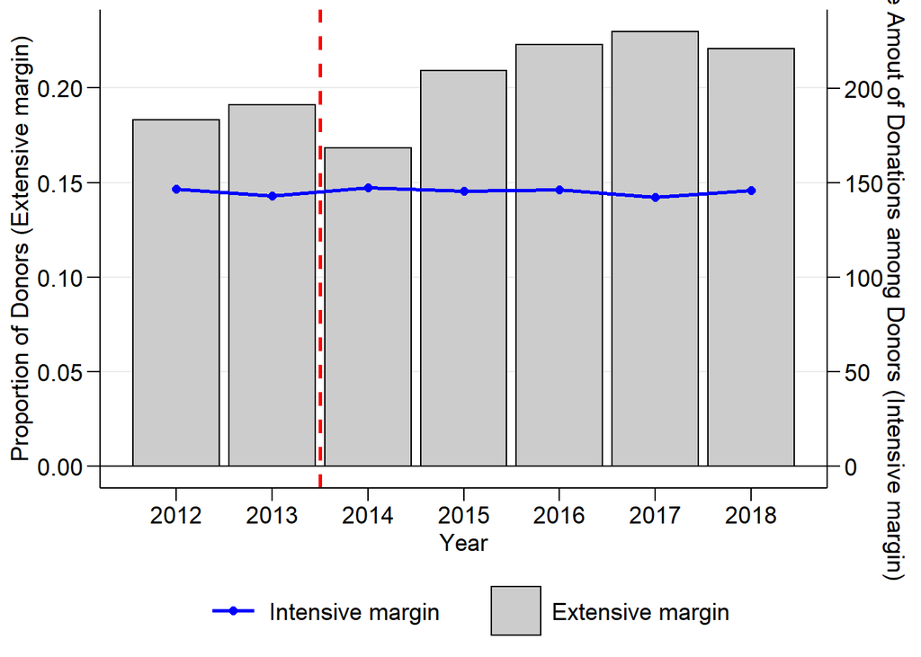

Proportion of Donors and Average Donations among Donors. Notes: The left and right axises respectively mesure proportion of donors and the average amount donations among donors. Authors made this graph based on NasTaB data.

The NaSTaB also asks respondents to answer whether they applied for a tax deduction of giving. Although this variable is unique, the sample size is relatively small due to unanswering. This survey investigates separately for the case of *total* income (for example, business income, dividend income, rental income) and the case of *labor* income. We make a dummy taking one if respondents applied for a business income deduction of giving or a labor income deduction of giving. Table @ref(tab:SummaryCovariate) shows the proportion of tax deduction is about 48%.

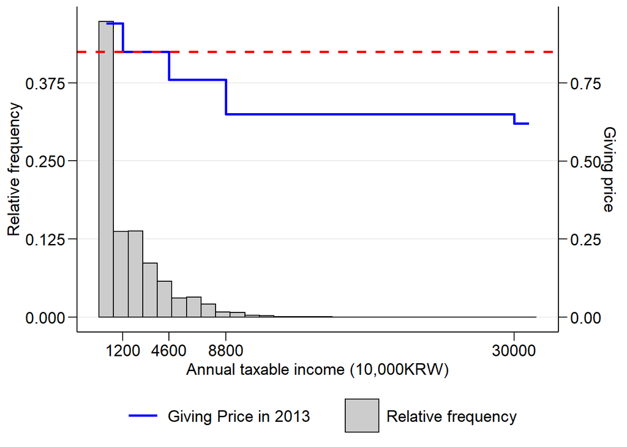

Income Distribution and Giving Price in 2013

[^1]: If it is difficult for investigators to meet subjects, another family member answers on behalf of him.
[^2]: Respondents answer the amount of donation for seven specific purposes last year. Seven specific purposes are policitical parties, educational organizations, social welfare organizations, organizations for culutre and art, religious groups, charity activies organaized by religious group, other purposes. We sum up the amount of donations, and consider it as the annual charitable giving.
[^3]: The giving price shown in Table @ref(tab:SummaryCovariate) is the *first* giving price. The giving price can be manipulated by an amount of donation. To avoid this endogeneity, we use the giving price where the amount of donation is zero. We will discuss this issue in the next section.